# Redox biogeochemistry

## Redox review

[video not shown]

4Fe$_{(s)}$ + 3O$_2$ $->$ 2Fe$_2$O$_{3s}$

## Redox sustains life

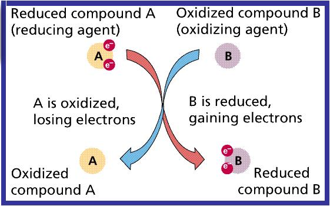

## Rules of redox

- Reduction/oxidation reactions
- Electrons are exchanged from one atom to another
- Atoms that gain electrons are called *reduced*
- Atoms that lose electrons are called *oxidized*
- Oxidation Is Loss Reduction Is Gain of electrons (OIL-RIG)

## Breaking down a redox reaction

4Fe$_{(s)}$ + 3O$_2$ $->$ 2Fe$_2$O$_{3s}$

## Oxidative state (or oxidation number)

- A simplified way of keeping track of electrons
- Follow the rules to figure it out:

## Rule 1

- If single element (or self-bonded element)-oxidation state of 0

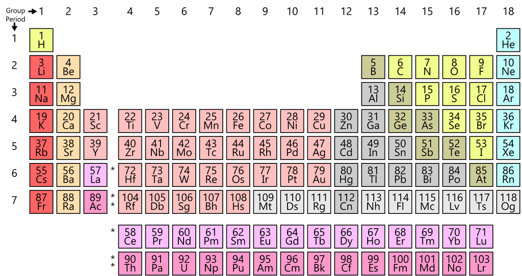

- O$_2$, H$_2$, Al, Ag, Hg, Fl$_2$

## Rule 2

- Monatomic ions have oxidation state of their charge
- Na$^+$, Cl$^-$

## Rule 3

- Alkali metals (far left of periodic table) = +1 oxidation number

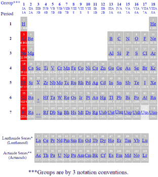

## Rule 3 (bonus)

[video not shown]

## Rule 3 (bonus explanation)

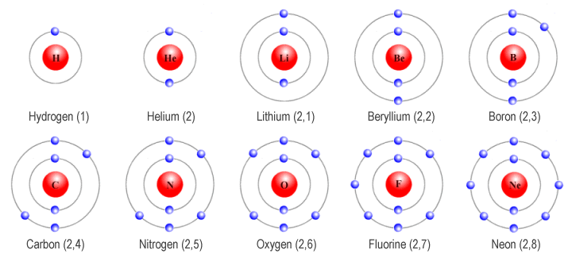

## Rule 4

- Alkaline metals (second from left on periodic table) have oxidation number of +2

## Rule 5

- Hydrogen is +1 when bonded to a non-metal
- Hydrogen is -1 when bonded to a metal

## Rule 6

- Oxygen is almost always -2
- Unless it is in a peroxide it is -1 (H$_2$O$_2$)

## Rule 7

- Fluorine is always -1

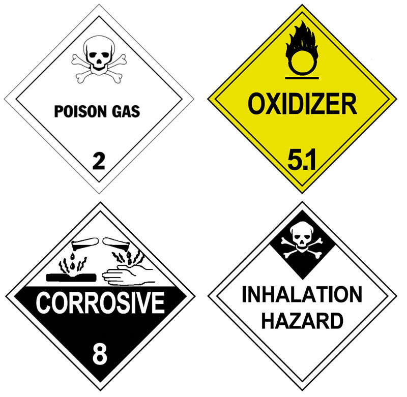

## Rule 8

- Sum of oxidation numbers in a molecule is zero or the charge of the molecule.
- NaCl, SO$_4^{2-}$

## Assigning oxidation number

In groups of 2 or 3 assign oxidation numbers to the following compounds

- C$_6$H$_{12}$O$_6$
- NO$_3^-$
- PO$_4^{3-}$
- NH$_3$
- NH$_4^+$
- CaCO$_3$

## Why do we care about oxidation number?

- The reactions that maintain life depend on electron exchange
- Chemical reactions need to be balanced by mass (moles of chemicals)
  - But also by electrons
- Understanding element, pollutant, and nutrient transformations requires knowing redox chemistry

## Redox potential

- Like pH … but electrons so pE

[figure not shown]

## Redox potential

[figure not shown]

from: [(Burgin et al., 2011)](https://esajournals.onlinelibrary.wiley.com/doi/full/10.1890/090227)

## Redox potential

[figure not shown]

## Redox ladder

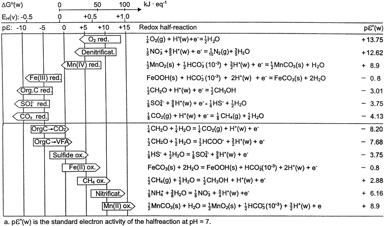

## Gibbs free energy

- Friday